# 628_HW3

For the first child, computing the things below:

```r
#3a ii
m1.var <- as.numeric(VarCorr(m1))[1:2]
#ZiGZi' for i=1 (id=1)
#Zi is a vector of '1' repeating 6 times, G is just the variance of b1i
est.ZGZ.m1.id1<-matrix(rep(m1.var[1]),nrow=6,ncol=6)
#est.ZGZ.m1.id1
#Ri for i=1 (id=1)
est.R.m1.id1<-m1.var[2]*diag(1,6)
#est.R.m1.id1

#put G and R components together, and output estimated cov(Yi=1):
est.cov_m1.id1<-est.ZGZ.m1.id1+est.R.m1.id1
print(est.cov_m1.id1)
```

```
##          [,1]     [,2]     [,3]     [,4]     [,5]     [,6]
## [1,] 659.1657 510.3377 510.3377 510.3377 510.3377 510.3377
## [2,] 510.3377 659.1657 510.3377 510.3377 510.3377 510.3377
## [3,] 510.3377 510.3377 659.1657 510.3377 510.3377 510.3377
## [4,] 510.3377 510.3377 510.3377 659.1657 510.3377 510.3377
## [5,] 510.3377 510.3377 510.3377 510.3377 659.1657 510.3377
## [6,] 510.3377 510.3377 510.3377 510.3377 510.3377 659.1657
```

```r
# The second way to do this
library(mgcv)
est.cov.m1 <- extract.lme.cov(m1)
est.cov.m1[1:6,1:6]
```

```
##          [,1]     [,2]     [,3]     [,4]     [,5]     [,6]
## [1,] 659.1658 510.3377 510.3377 510.3377 510.3377 510.3377
## [2,] 510.3377 659.1658 510.3377 510.3377 510.3377 510.3377
## [3,] 510.3377 510.3377 659.1658 510.3377 510.3377 510.3377
## [4,] 510.3377 510.3377 510.3377 659.1658 510.3377 510.3377
## [5,] 510.3377 510.3377 510.3377 510.3377 659.1658 510.3377
## [6,] 510.3377 510.3377 510.3377 510.3377 510.3377 659.1658
```

This is the covariance matrix for Yi (Σi) for a child and the patterns in the variances and covariances is that 659.1658 in the diagonal line and the others are all 510.3377.

```r
#3a iii
# Obtain empirical BLUPs  from m1
m1.re <- as.data.frame(random.effects(m1))
apply(m1.re, 2, var)
```

```
## (Intercept)
##    481.0597
```

empirical BLUPs and obtain their variance is 481.0597. In 3ai is 510.34. SO they are different. Because empirical BLUPs more like marginal mean which is smaller.

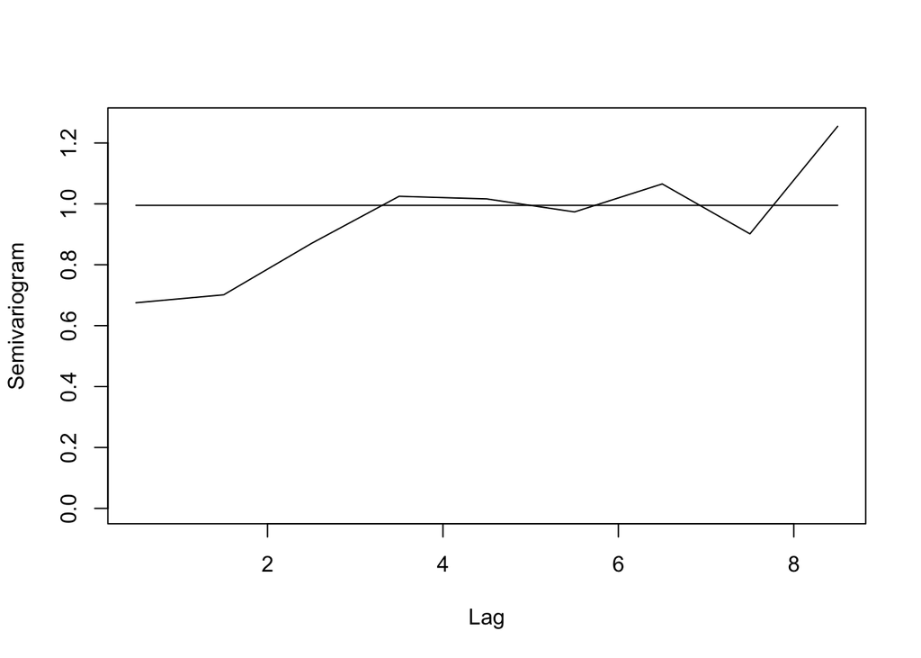

```
## $bin.mids
## [1] 0.5 1.5 2.5 3.5 4.5 5.5 6.5 7.5 8.5
##
## $bin.means
## [1] 0.6752752 0.7013087 0.8699806 1.0249171 1.0162853 0.9735594 1.0654988
## [8] 0.9015042 1.2545613
##
## $bin.sizes
## [1]  585 1080  923  794  638  473  341  198   65
##
## $process.var
## [1] 0.9951882
```

```r
#3a iv
#install.packages("mgcv")
#Create a data frame with variables needed for residual analysis
#Transform the residuals based on the Cholesky decomposition of the covariance matrix for
library(mgcv)
est.cov1 <- extract.lme.cov(m1)
cr.1<- solve(t(chol(est.cov1))) %*% residuals(m1, level=0) #level=0 is marginal residuals
source("Semivariogram Function.r")
#Empirical semi-variogram for transformed residuals for m4
variogram(resid=cr.1[,1],timeVar=df2$AGEL,id=df2$ID,irregular=T,binwidth=1,numElems=5)
```

Whether the covariance model fits the data well or not: The model fits well from lag4 to lag6.

```r
#3b
m2 <- gls(FEV1 ~ AGE0+AGEL+FEMALE+F508_1+F508_2+AGEL*FEMALE+AGEL*F508_1+AGEL*F508_2, data=df2,
          corr=corCompSymm(form= ~ 1 | ID))
summary(m2)
```

```
## Generalized least squares fit by REML
##   Model: FEV1 ~ AGE0 + AGEL + FEMALE + F508_1 + F508_2 + AGEL * FEMALE +      AGEL * F508_1 + AGEL * F508_2
##   Data: df2
##        AIC      BIC    logLik
##   12512.41 12570.88 -6245.207
##
## Correlation Structure: Compound symmetry
##  Formula: ~1 | ID
##  Parameter estimate(s):
##       Rho
## 0.7742176
##
## Coefficients:
##                  Value Std.Error   t-value p-value
## (Intercept)  103.81003  6.703757 15.485350  0.0000
## AGE0          -1.85437  0.334193 -5.548804  0.0000
## AGEL          -0.59043  0.393142 -1.501831  0.1334
## FEMALE1       -1.19867  3.397055 -0.352856  0.7242
## F508_1        -4.27993  5.609198 -0.763020  0.4456
## F508_2        -6.77695  5.640915 -1.201392  0.2298
## AGEL:FEMALE1  -0.81968  0.249580 -3.284231  0.0010
## AGEL:F508_1   -0.48790  0.422543 -1.154682  0.2484
## AGEL:F508_2   -0.65120  0.421501 -1.544959  0.1226
##
##  Correlation:
##              (Intr) AGE0   AGEL   FEMALE F508_1 F508_2 AGEL:FE AGEL:F508_1
## AGE0         -0.630
## AGEL         -0.213  0.006
## FEMALE1      -0.164 -0.088  0.073
## F508_1       -0.657 -0.002  0.229 -0.021
## F508_2       -0.725  0.123  0.227 -0.062  0.788
## AGEL:FEMALE1  0.062 -0.005 -0.272 -0.262  0.004  0.011
## AGEL:F508_1   0.181 -0.004 -0.856  0.005 -0.267 -0.214 -0.022
## AGEL:F508_2   0.179 -0.003 -0.853  0.011 -0.215 -0.267 -0.040   0.805
##
## Standardized residuals:
##         Min          Q1         Med          Q3         Max
## -2.66105343 -0.73281710  0.01613678  0.73390919  3.18697375
##
## Residual standard error: 25.67422
## Degrees of freedom: 1512 total; 1503 residual
```

3c

The variance covariance matrix for the model m1 in 3a and m2 in 3b are very similar.

The model for the m1 is lme with only the intercept. Yij = beta0 + beta1*ti+…+b1i+error

The merginal mean response is beta0 + beta1*ti+…+ betap*xij and it is the same as the Compound Symmetry model.

```r
#3c
getVarCov(m2)
```

```
## Marginal variance covariance matrix
##        [,1]   [,2]   [,3]   [,4]   [,5]   [,6]
## [1,] 659.17 510.34 510.34 510.34 510.34 510.34
## [2,] 510.34 659.17 510.34 510.34 510.34 510.34
## [3,] 510.34 510.34 659.17 510.34 510.34 510.34
## [4,] 510.34 510.34 510.34 659.17 510.34 510.34
## [5,] 510.34 510.34 510.34 510.34 659.17 510.34
## [6,] 510.34 510.34 510.34 510.34 510.34 659.17
##   Standard Deviations: 25.674 25.674 25.674 25.674 25.674 25.674
```

4a

b1i is the mean response for each person’s level among iteration b2i is the slope difference for each person’s level among iteration

```r
#4a i
m3 <- lme(FEV1 ~ AGE0+AGEL+FEMALE+F508_1+F508_2+AGEL*FEMALE+AGEL*F508_1+AGEL*F508_2, data=df2,
          random= ~ AGEL | ID)
summary(m3)
```

```
## Linear mixed-effects model fit by REML
##   Data: df2
##        AIC      BIC    logLik
##   12407.24 12476.34 -6190.619
##
## Random effects:
##  Formula: ~AGEL | ID
##  Structure: General positive-definite, Log-Cholesky parametrization
##             StdDev    Corr
## (Intercept) 22.615530 (Intr)
## AGEL         2.126875 -0.157
## Residual    10.863346
##
## Fixed effects:  FEV1 ~ AGE0 + AGEL + FEMALE + F508_1 + F508_2 + AGEL * FEMALE +      AGEL * F508_1 + AGEL * F508_2
##                  Value Std.Error   DF   t-value p-value
## (Intercept)  104.52800  6.639457 1308 15.743456  0.0000
## AGE0          -1.90971  0.330869  195 -5.771792  0.0000
## AGEL          -0.60673  0.590730 1308 -1.027087  0.3046
## FEMALE1       -1.34560  3.367527  195 -0.399580  0.6899
## F508_1        -4.23639  5.558898  195 -0.762092  0.4469
## F508_2        -6.69784  5.589881  195 -1.198208  0.2323
## AGEL:FEMALE1  -0.75318  0.381599 1308 -1.973747  0.0486
## AGEL:F508_1   -0.50057  0.636206 1308 -0.786802  0.4315
## AGEL:F508_2   -0.73638  0.635018 1308 -1.159619  0.2464
##  Correlation:
##              (Intr) AGE0   AGEL   FEMALE F508_1 F508_2 AGEL:FE AGEL:F508_1
## AGE0         -0.630
## AGEL         -0.210  0.002
## FEMALE1      -0.164 -0.088  0.074
## F508_1       -0.657 -0.002  0.229 -0.021
## F508_2       -0.725  0.122  0.226 -0.062  0.788
## AGEL:FEMALE1  0.060 -0.002 -0.279 -0.264  0.005  0.012
## AGEL:F508_1   0.178 -0.001 -0.850  0.005 -0.268 -0.213 -0.023
## AGEL:F508_2   0.177  0.000 -0.845  0.012 -0.214 -0.267 -0.046   0.797
##
## Standardized Within-Group Residuals:
##          Min           Q1          Med           Q3          Max
## -5.328879738 -0.461215172  0.004543523  0.477952649  4.320075963
##
## Number of Observations: 1512
## Number of Groups: 200
```

```r
getVarCov(m3)
```

```
## Random effects variance covariance matrix
##             (Intercept)    AGEL
## (Intercept)    511.4600 -7.5506
## AGEL            -7.5506  4.5236
##   Standard Deviations: 22.616 2.1269
```

```r
#make G matrix:
G.m3.col1 <- as.numeric(getVarCov(m3)[1:2,1])#extract first column of getVarCov(m2)

G.m3.col2 <- as.numeric(getVarCov(m3)[1:2,2])#extract second column of getVarCov(m2)


G.m3<-cbind(G.m3.col1,G.m3.col2)
#Calculate Intraclass Correlation Coefficient (ICC)
library(mgcv)
est.cov.m3 <- extract.lme.cov(m3)
est.cov.m3[1:6,1:6]
```

```
##          [,1]     [,2]     [,3]     [,4]     [,5]     [,6]
## [1,] 624.9716 500.8939 496.3358 485.4943 479.5803 472.8490
## [2,] 500.8939 617.3825 498.2252 495.5017 494.0160 492.3251
## [3,] 496.3358 498.2252 617.6573 503.0222 504.8644 506.9613
## [4,] 485.4943 495.5017 503.0222 638.9219 530.6673 541.7732
## [5,] 479.5803 494.0160 504.8644 530.6673 662.7551 560.7634
## [6,] 472.8490 492.3251 506.9613 541.7732 560.7634 700.3898
```

```r
#4a ii
zi1<-rep(1,times=6)
zi2<-df2[df2$ID==100073,]$AGEL
zi_id1<-cbind(zi1,zi2)
t.zi_id1=t(zi_id1)
est.ZGZ.m3.id1<-zi_id1%*%G.m3%*%t.zi_id1
est.ZGZ.m3.id1
```

```
##          [,1]     [,2]     [,3]     [,4]     [,5]     [,6]
## [1,] 506.9593 500.8939 496.3358 485.4943 479.5803 472.8490
## [2,] 500.8939 499.3702 498.2252 495.5017 494.0160 492.3251
## [3,] 496.3358 498.2252 499.6450 503.0222 504.8644 506.9613
## [4,] 485.4943 495.5017 503.0222 520.9096 530.6673 541.7732
## [5,] 479.5803 494.0160 504.8644 530.6673 544.7429 560.7634
## [6,] 472.8490 492.3251 506.9613 541.7732 560.7634 582.3775
```

```r
#Ri for i=1 (id=1)
est.R.m3.id1<-as.numeric(VarCorr(m3)[3])*diag(1,6)
#put G and R components together, and output estimated cov(Yi=1):
est.cov_m3.id1<-est.ZGZ.m3.id1+est.R.m3.id1
print(est.cov_m3.id1)
```

```
##          [,1]     [,2]     [,3]     [,4]     [,5]     [,6]
## [1,] 624.9716 500.8939 496.3358 485.4943 479.5803 472.8490
## [2,] 500.8939 617.3825 498.2252 495.5017 494.0160 492.3251
## [3,] 496.3358 498.2252 617.6573 503.0222 504.8644 506.9613
## [4,] 485.4943 495.5017 503.0222 638.9219 530.6673 541.7732
## [5,] 479.5803 494.0160 504.8644 530.6673 662.7551 560.7634
## [6,] 472.8490 492.3251 506.9613 541.7732 560.7634 700.3898
```

```r
#4a iii
m3.re <- as.data.frame(random.effects(m3))
apply(m3.re, 2, var)
```

```
## (Intercept)        AGEL
##  466.606708    2.794081
```

The BULP value is also smaller compared with 4a i.

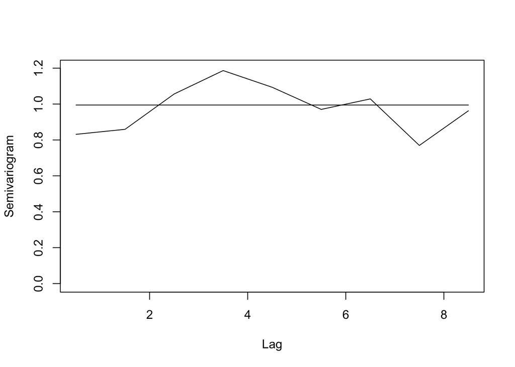

```
## $bin.mids
## [1] 0.5 1.5 2.5 3.5 4.5 5.5 6.5 7.5 8.5
##
## $bin.means
## [1] 0.8313781 0.8592894 1.0560627 1.1866220 1.0935251 0.9702715 1.0287409
## [8] 0.7694824 0.9625904
##
## $bin.sizes
## [1]  585 1080  923  794  638  473  341  198   65
##
## $process.var
## [1] 0.9947102
```

```r
#4 iv
est.cov3 <- extract.lme.cov(m3)
cr.3<- solve(t(chol(est.cov3))) %*% residuals(m3, level=0) #level=0 is marginal residuals
source("Semivariogram Function.r")
#Empirical semi-variogram for transformed residuals
variogram(resid=cr.3[,1],timeVar=df2$AGEL,id=df2$ID,irregular=T,binwidth=1,numElems=5)
```

```r
#4b
anova(m3,m1)
```

```
##    Model df      AIC      BIC    logLik   Test  L.Ratio p-value
## m3     1 13 12407.24 12476.34 -6190.619
## m1     2 11 12512.42 12570.88 -6245.207 1 vs 2 109.1768  <.0001
```

H0 is b3i = 0 We should choose the m3 since the p value is smaller than the 0.0001. Which means we need to choose the model with slope AGEL.

```r
#5a
m5 <- lme(FEV1 ~ AGE0+AGEL+FEMALE+F508_1+F508_2, data=df2,method="ML",
          random= ~ AGEL | ID)
m6 <- lme(FEV1 ~ AGE+FEMALE+F508_1+F508_2, data=df2,method="ML",
          random= ~ AGE| ID)
anova(m5,m6)
```

```
##    Model df      AIC      BIC    logLik   Test  L.Ratio p-value
## m5     1 10 12421.98 12475.19 -6200.988
## m6     2  9 12435.62 12483.51 -6208.811 1 vs 2 15.64599   1e-04
```

```r
#5b
m7 =  lme(FEV1 ~ AGE+FEMALE+AGEL*F508_1+AGEL*F508_2, data=df2,method="ML",
          random= ~ AGEL | ID)
anova(m5,m7)
```

```
##    Model df      AIC      BIC    logLik   Test  L.Ratio p-value
## m5     1 10 12421.98 12475.19 -6200.988
## m7     2 12 12424.34 12488.20 -6200.172 1 vs 2 1.631394  0.4423
```

since the p value =0.4423 and is greater than 0.05, so we cannot reject the null hypothesis. Which means there is no significant contribution of genotype to the change in FEV1 over time.

```r
#5c
m8 =  lme(FEV1 ~ AGE+FEMALE+F508_1+F508_2+AGEL*FEMALE, data=df2,method="ML",
          random= ~ AGEL | ID)
anova(m5,m8)
```

```
##    Model df      AIC      BIC    logLik   Test  L.Ratio p-value
## m5     1 10 12421.98 12475.19 -6200.988
## m8     2 11 12419.82 12478.36 -6198.912 1 vs 2 4.152138  0.0416
```

since the p value =0.0416 and is smaller than 0.05, so we reject the null hypothesis. Which means there is a significant contribution of gender to the change in FEV1 over time. Choose m8 as the best model.

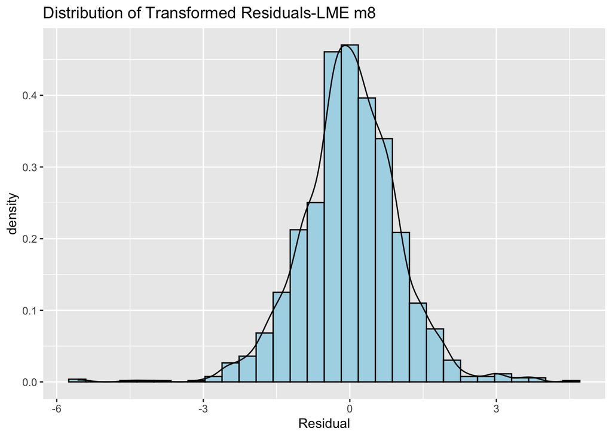

```r
#5d
#since m8 is the final model I choose
est.cov8 <- extract.lme.cov(m8)
cr.8 <- solve(t(chol(est.cov8))) %*% residuals(m8, level=0) #level=0 is marginal residuals
pred8 <- data.frame(id=df2$ID,female=df2$FEMALE,age=df2$AGE,
                     pred=fitted(m8, level=0), resid=cr.8[,1])
ggplot(pred8, aes(x=resid))+
  geom_histogram(aes(y=..density..), color="black", fill="lightblue") +
  geom_density() + labs(title="Distribution of Transformed Residuals-LME m8", x="Residual")
```

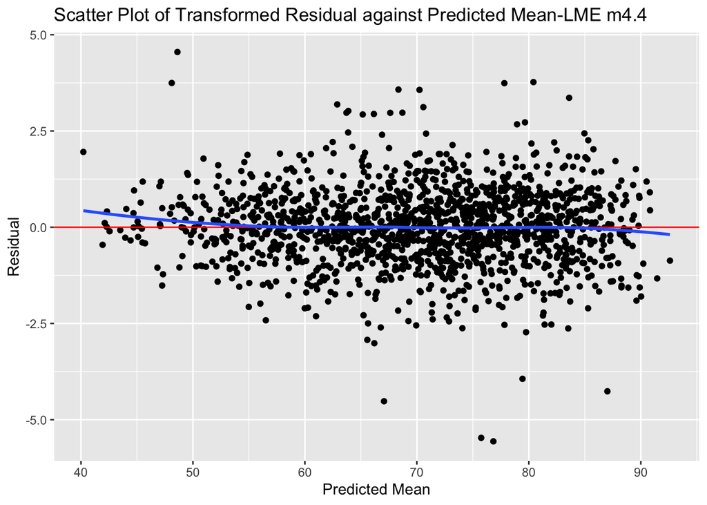

```r
ggplot(pred8, aes(x=pred, y=resid)) +
  geom_point() + geom_hline(yintercept=0,colour="red") +
  geom_smooth(method="loess", se=F) +
  labs(title="Scatter Plot of Transformed Residual against Predicted Mean-LME m4.4",
       x="Predicted Mean", y="Residual")
```

```r
#5e
#covariance
extract.lme.cov(m8)[1:6, 1:6]
```

```
##          [,1]     [,2]     [,3]     [,4]     [,5]     [,6]
## [1,] 611.7893 487.8010 483.3396 472.7282 466.9397 460.3513
## [2,] 487.8010 604.3500 485.1693 482.4835 481.0185 479.3509
## [3,] 483.3396 485.1693 604.5958 489.8146 491.5986 493.6292
## [4,] 472.7282 482.4835 489.8146 625.3031 516.7634 527.5897
## [5,] 466.9397 481.0185 491.5986 516.7634 648.5425 546.1153
## [6,] 460.3513 479.3509 493.6292 527.5897 546.1153 685.2524
```